# Reproducible Research: Peer Assessment 1

## Loading and preprocessing the data

Load the activity data into the data frame variable (act). And correct the date format

```r
setwd("F:/DataScience/coursera/05_ReproducibleResearch/week2")
act <- read.csv("activity.csv")
act$date<- as.Date(act$date, format="%Y-%m-%d")
```

## What is mean total number of steps taken per day?

For this part of the assignment, we’ll ignore the missing values in the dataset. act1 : The subset of the activity data without missing steps values

```r
act1 <- subset(act, !is.na(steps))
```

calculate the sum steps by day, create histogram of the daily total number of steps taken

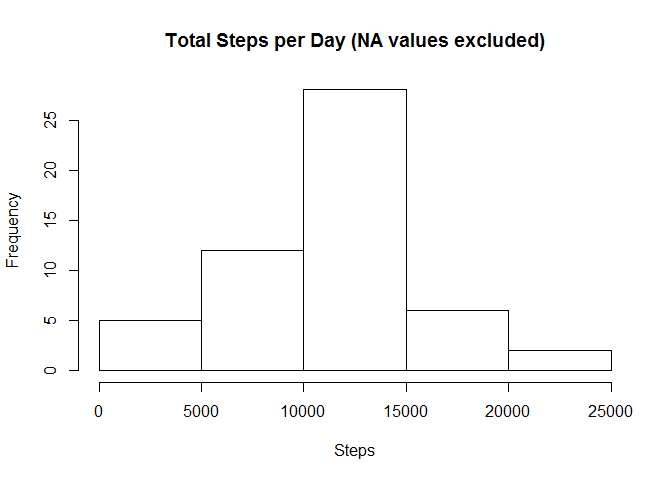

```r
TotalStepsPerDay <- aggregate(act1$steps, by=list(date=act1$date), FUN=sum, na.rm = TRUE)
names(TotalStepsPerDay) <- c("date", "steps")
hist(TotalStepsPerDay$steps, breaks=5, xlab="Steps", main = "Total Steps per Day (NA values excluded)")
```

The mean and median total number of steps taken per day

```r
mean(TotalStepsPerDay$steps, na.rm = TRUE)
```

```
## [1] 10766.19
```

```r
median(TotalStepsPerDay$steps, na.rm = TRUE)
```

```
## [1] 10765
```

## What is the average daily activity pattern?

Calculate average steps for each interval for all days.

```r
AverageStepsPerInt <- aggregate(act1$steps, by=list(interval=act1$interval), FUN=mean, na.rm = TRUE)
names(AverageStepsPerInt) <- c("interval", "steps")
```

Plot the Average Number Steps per Day by Interval.

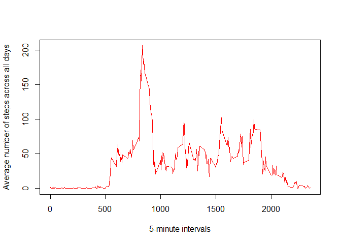

```r
with(AverageStepsPerInt,plot(interval,steps,type="l",xlab="5-minute intervals", ylab="Average number of steps across all days", col="red"))
```

Interval with most average steps.

```r
AverageStepsPerInt$interval[which.max(AverageStepsPerInt$steps)]
```

```
## [1] 835
```